# HR- Analytics

Ayan Dey

2024-01-31

# HR-Analytics

Explore the dynamics of human resources through insightful Analytics in my HR Analytics project. This project is about HR metrics, providing valuable insights to optimize workforce management and enhance organizational performance.  
## Processes  
This project’s primary goal is to create Dashboard, but before dashboard it is necessary to clean and organised the data, To understand,clean and organised the data I use **R programming** on R Studio Platform. After, ensure the data is cleaned and organised, I push the data into ta database, then I use **Apache Superset** to create interactive Dashboard. Though There is not much opensource Hosting site to Embedded Superset dashboard, so I put all those screenshot in this R Markdown.

```r
# setting-up working directory
getwd()
```

```
## [1] "/home/ayan/project/HR-Analytics"
```

```r
# importing libraries
library(tidyverse)
library(visdat)
library(odbc)
library(DBI)
```

```r
# importing data
data <- read.csv("HR_Analytics.csv", header = TRUE)
head(data)
```

```
##   EmpID Age AgeGroup Attrition    BusinessTravel DailyRate
## 1 RM297  18    18-25       Yes     Travel_Rarely       230
## 2 RM302  18    18-25        No     Travel_Rarely       812
## 3 RM458  18    18-25       Yes Travel_Frequently      1306
## 4 RM728  18    18-25        No        Non-Travel       287
## 5 RM829  18    18-25       Yes        Non-Travel       247
## 6 RM973  18    18-25        No        Non-Travel      1124
##               Department DistanceFromHome Education EducationField
## 1 Research & Development                3         3  Life Sciences
## 2                  Sales               10         3        Medical
## 3                  Sales                5         3      Marketing
## 4 Research & Development                5         2  Life Sciences
## 5 Research & Development                8         1        Medical
## 6 Research & Development                1         3  Life Sciences
##   EmployeeCount EmployeeNumber EnvironmentSatisfaction Gender HourlyRate
```

[output cut: 48 more lines]

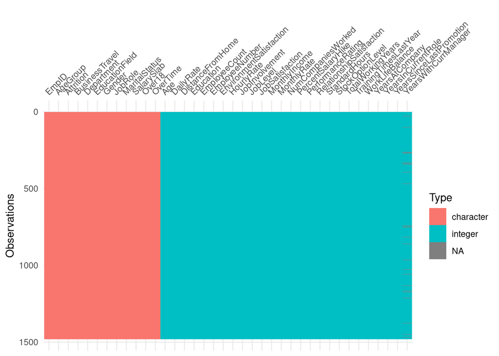

```r
# over-looking the entire data
vis_dat(data)
```

Its shows last variable have some NULL values

```r
# look null values Boolean
any(is.na(data))
```

```
## [1] TRUE
```

```r
# locate the Null values
which(is.na(data), arr.ind = TRUE)
```

```
##        row col
##  [1,]   29  38
##  [2,]   32  38
##  [3,]   46  38
##  [4,]  100  38
##  [5,]  101  38
##  [6,]  104  38
##  [7,]  223  38
##  [8,]  263  38
##  [9,]  265  38
## [10,]  269  38
## [11,]  270  38
## [12,]  330  38
## [13,]  337  38
## [14,]  338  38
```

[output cut: 43 more lines]

There is many NULL values in the 38 th column. **NOTED**

```r
# 38 th column overlook
head(data[38])
```

```
##   YearsWithCurrManager
## 1                    0
## 2                    0
## 3                    0
## 4                    0
## 5                    0
## 6                    0
```

```r
glimpse(data)
```

```
## Rows: 1,480
## Columns: 38
## $ EmpID                    <chr> "RM297", "RM302", "RM458", "RM728", "RM829", …
## $ Age                      <int> 18, 18, 18, 18, 18, 18, 18, 18, 19, 19, 19, 1…
## $ AgeGroup                 <chr> "18-25", "18-25", "18-25", "18-25", "18-25", …
## $ Attrition                <chr> "Yes", "No", "Yes", "No", "Yes", "No", "Yes",…
## $ BusinessTravel           <chr> "Travel_Rarely", "Travel_Rarely", "Travel_Fre…
## $ DailyRate                <int> 230, 812, 1306, 287, 247, 1124, 544, 1431, 52…
## $ Department               <chr> "Research & Development", "Sales", "Sales", "…
## $ DistanceFromHome         <int> 3, 10, 5, 5, 8, 1, 3, 14, 22, 3, 1, 2, 2, 21,…
## $ Education                <int> 3, 3, 3, 2, 1, 3, 2, 3, 1, 1, 1, 3, 2, 3, 2, …
## $ EducationField           <chr> "Life Sciences", "Medical", "Marketing", "Lif…
## $ EmployeeCount            <int> 1, 1, 1, 1, 1, 1, 1, 1, 1, 1, 1, 1, 1, 1, 1, …
## $ EmployeeNumber           <int> 405, 411, 614, 1012, 1156, 1368, 1624, 1839, …
## $ EnvironmentSatisfaction  <int> 3, 4, 2, 2, 3, 4, 2, 2, 4, 2, 3, 2, 1, 4, 3, …
```

[output cut: 25 more lines]

No need the 38 th column for this Analysis.

```r
data <- subset(data, select = -YearsWithCurrManager)
```

```r
glimpse(data)
```

```
## Rows: 1,480
## Columns: 37
## $ EmpID                    <chr> "RM297", "RM302", "RM458", "RM728", "RM829", …
## $ Age                      <int> 18, 18, 18, 18, 18, 18, 18, 18, 19, 19, 19, 1…
## $ AgeGroup                 <chr> "18-25", "18-25", "18-25", "18-25", "18-25", …
## $ Attrition                <chr> "Yes", "No", "Yes", "No", "Yes", "No", "Yes",…
## $ BusinessTravel           <chr> "Travel_Rarely", "Travel_Rarely", "Travel_Fre…
## $ DailyRate                <int> 230, 812, 1306, 287, 247, 1124, 544, 1431, 52…
## $ Department               <chr> "Research & Development", "Sales", "Sales", "…
## $ DistanceFromHome         <int> 3, 10, 5, 5, 8, 1, 3, 14, 22, 3, 1, 2, 2, 21,…
## $ Education                <int> 3, 3, 3, 2, 1, 3, 2, 3, 1, 1, 1, 3, 2, 3, 2, …
## $ EducationField           <chr> "Life Sciences", "Medical", "Marketing", "Lif…
## $ EmployeeCount            <int> 1, 1, 1, 1, 1, 1, 1, 1, 1, 1, 1, 1, 1, 1, 1, …
## $ EmployeeNumber           <int> 405, 411, 614, 1012, 1156, 1368, 1624, 1839, …
## $ EnvironmentSatisfaction  <int> 3, 4, 2, 2, 3, 4, 2, 2, 4, 2, 3, 2, 1, 4, 3, …
```

[output cut: 24 more lines]

```r
# see the factor values
table(data$Attrition)
```

```
##
##   No  Yes
## 1242  238
```

```r
# convert the data type as factor of Attrition variable
data$Attrition <- as.factor(data$Attrition)
```

```r
# check the data type of Attrition variable
class(data$Attrition)
```

```
## [1] "factor"
```

```r
# create a new variable for Analysis
data <- data %>%
  mutate(Attrition_vector = ifelse(Attrition == "yes", 1, 0))
```

```r
# see the mapping
data %>% select(Attrition,Attrition_vector) %>% head(10)
```

```
##    Attrition Attrition_vector
## 1        Yes                0
## 2         No                0
## 3        Yes                0
## 4         No                0
## 5        Yes                0
## 6         No                0
## 7        Yes                0
## 8         No                0
## 9        Yes                0
## 10        No                0
```

its look not done .. miss mapping..  
let make it ..

```r
# delete the newly created column due to miss mapping
data <- data %>% select(- Attrition_vector)
```

```r
# create again that new variable
data <- data %>%
  mutate(Attrition_vector = ifelse(Attrition == "Yes", 1, 0))
```

```r
# see the mapping
data %>% select(Attrition,Attrition_vector) %>% head(10)
```

```
##    Attrition Attrition_vector
## 1        Yes                1
## 2         No                0
## 3        Yes                1
## 4         No                0
## 5        Yes                1
## 6         No                0
## 7        Yes                1
## 8         No                0
## 9        Yes                1
## 10        No                0
```

```r
# convert the Attrition_vector column as numeric
data$Attrition_vector <- as.integer(data$Attrition_vector)
```

```r
class(data$Attrition_vector)
```

```
## [1] "integer"
```

Now the Attrition response converted in to a numeric vector.

```r
# View(data)
```

### Now its Time to push the data into database

+++++++++++++++++++++++++++++++++++++++++++++++++++++++++++++++++++++++++++++++++++++

```r
knitr::opts_chunk$set(echo = TRUE)
# connecting with database
con <- dbConnect(odbc::odbc(),
                 driver = "PostgreSQL Unicode",
                 server = "localhost",
                 port = 5432,
                 database = "codeone",
                 uid = "postgres",
                 pwd = "13599")
```

++++++++++++++++++++++++++++++++++++++++++++++++++++++++++++++++++++++++++++++++++++++

```r
# let see the list of table in the connected database
dbListTables(con)
```

```
##  [1] "actor"                      "actor_info"
##  [3] "address"                    "category"
##  [5] "city"                       "country"
##  [7] "customer"                   "customer_list"
##  [9] "film"                       "film_actor"
## [11] "film_category"              "film_list"
## [13] "inventory"                  "language"
## [15] "nicer_but_slower_film_list" "payment"
## [17] "penguins"                   "rental"
## [19] "sales_by_film_category"     "sales_by_store"
## [21] "staff"                      "staff_list"
## [23] "store"
```

```r
# rename the data-frame before push into data base
hr_analytics_data <- data
```

```r
# now push the data-frame into database
copy_to(con,hr_analytics_data,temporary=FALSE)
```

```r
# verify is the data inserted into the data base
dbListTables(con)
```

```
##  [1] "actor"                      "actor_info"
##  [3] "address"                    "category"
##  [5] "city"                       "country"
##  [7] "customer"                   "customer_list"
##  [9] "film"                       "film_actor"
## [11] "film_category"              "film_list"
## [13] "hr_analytics_data"          "inventory"
## [15] "language"                   "nicer_but_slower_film_list"
## [17] "payment"                    "penguins"
## [19] "rental"                     "sales_by_film_category"
## [21] "sales_by_store"             "staff"
## [23] "staff_list"                 "store"
```

Now the cleaned data inserted into the data-base.

```r
# check data type of all variable after pushing into database
query <- "SELECT column_name, data_type FROM information_schema.columns WHERE table_name = 'hr_analytics_data';"
result <- dbGetQuery(con, query)
result
```

```
##                 column_name data_type
## 1                     EmpID      text
## 2                       Age   integer
## 3                  AgeGroup      text
## 4                 Attrition      text
## 5            BusinessTravel      text
## 6                 DailyRate   integer
## 7                Department      text
## 8          DistanceFromHome   integer
## 9                 Education   integer
## 10           EducationField      text
## 11            EmployeeCount   integer
## 12           EmployeeNumber   integer
## 13  EnvironmentSatisfaction   integer
## 14                   Gender      text
```

[output cut: 24 more lines]

Now to make dashboard work on RStudio and Apache-Superset Simultaneously.

[figure not shown]

## Dashboard  
- SQL code while making Dashboard

```r
# Attrition Percentage :: Edit Data :: Metrics ::
# (sum("Attrition_vector")/COUNT(*)::DECIMAL)*100
```

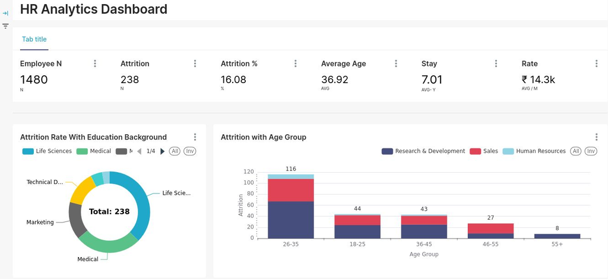

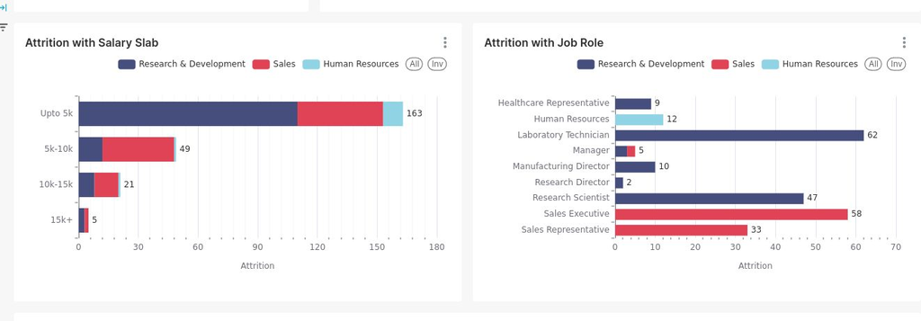

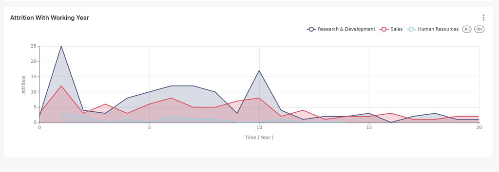

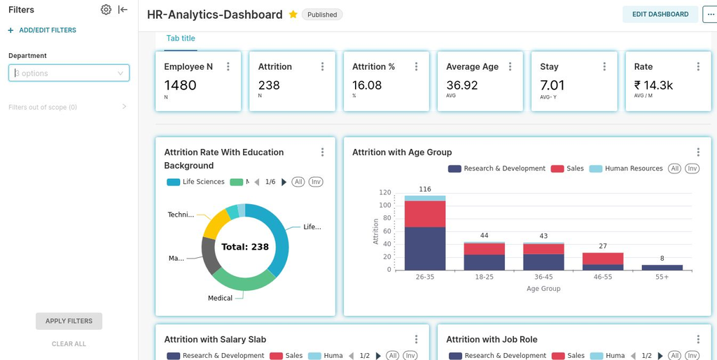

- Now Let Apply filter to overview of the Research And Development Department.

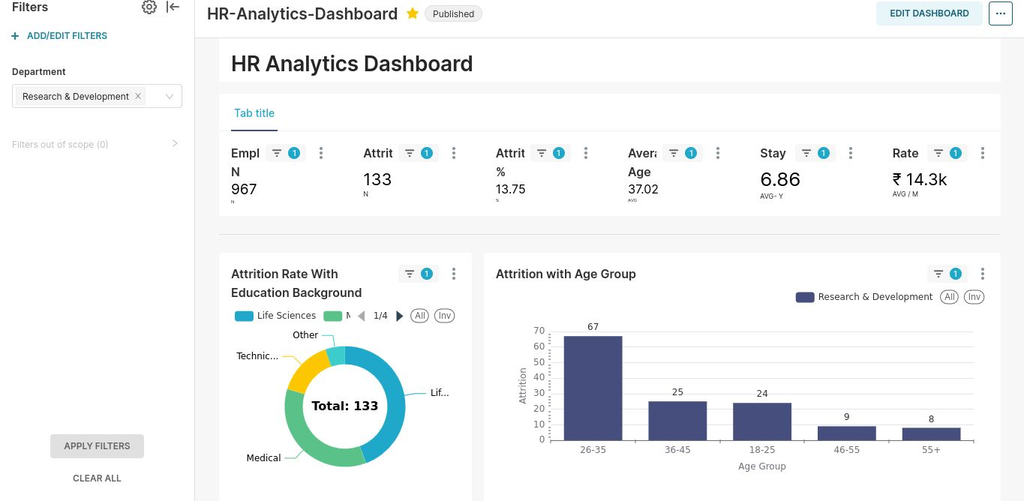

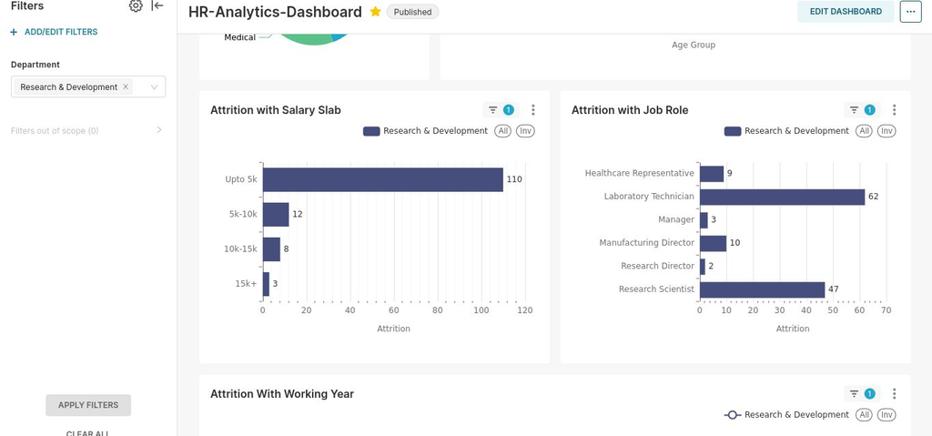

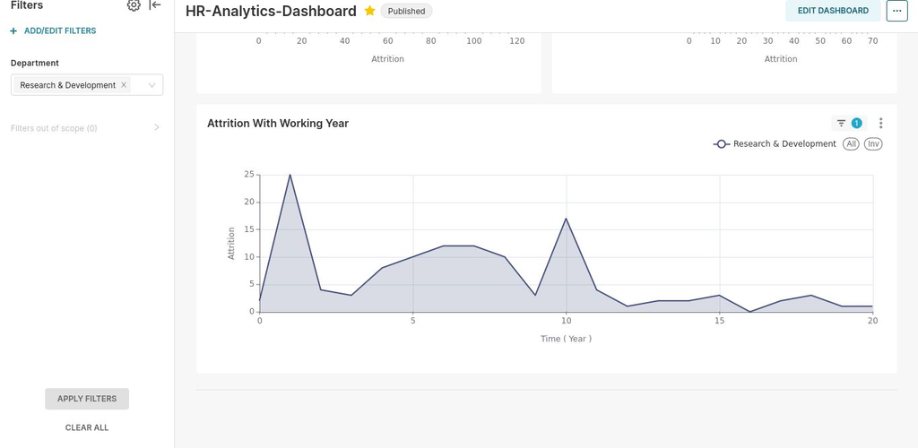